# QCC: Quality Control Charts

1/2/2021 – Tesina S.A.A.D.

## Controllo e miglioramento della qualità

La **qualità** di un prodotto e/o di un servizio gioca un ruolo fondamentale in ambito industriale.

La qualità di un prodotto può essere valutata misurandone varie caratteristiche, come: performance, affidabilità, durabilità, conformità agli standard, estetica, funzionalità etc.

In relazione a queste caratteristiche può essere data una definizione più formale:

> **La qualità è inversamente proporzionale alla variabilità**

dove con *variabilità* si intendono variazioni delle caratteristiche elencate.

L’**ingegneria della qualità** è un insieme di attività che una compagnia svolge al fine di assicurarsi che:

- le caratteristiche di un prodotto rientrino negli standard qualitativi richiesti;
- la variabilità attorno a questi valori sia più bassa possibile.

Quindi **controllare** la qualità di un prodotto significa **controllare la variabilità** introdotta in fase di produzione.

Per controllare e misurare la variabilità dei prodotti e dei processi efficacemente è necessario fare uso di **metodi statistici**.

## Metodi statistici per il controllo qualità

I metodi statistici a supporto delle attività dell’ingegneria della qualità possono essere suddivisi principalmente in tre aree:

- **Controllo statistico di processo** (**SPC** - *Statistical process control*);
- **Progettazione di esperimenti** (**DoE** - *Design of experiments*);
- **Controllo di accettazione** (*Acceptance sampling*).

## Controllo statistico di processo - SPC

L’SPC può essere definito, in modo sintetico, come:

> **l’applicazione di tecniche statistiche per comprendere ed analizzare le variabilità di un processo.**

L’SPC fa largo uso dei **diagrammi di controllo**.

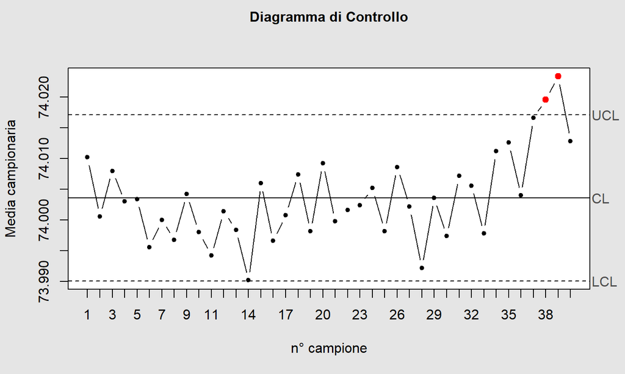

## Diagrammi di controllo

I diagrammi di controllo (o diagrammi **Shewhart**) sono strumenti di controllo statistico di processo impiegati per il monitoraggio di una caratteristica qualitativa di un prodotto.

Le componenti principali sono:

- due **limiti di controllo**: superiore e inferiore (UCL - LCL)
- un valore medio (target - valore nominale della caratteristica controllata)

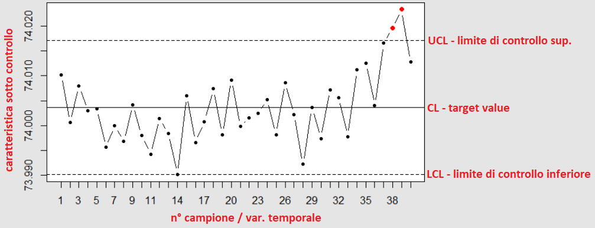

Il diagramma traccia l’andamento di una caratteristica qualitativa del prodotto da tenere sotto controllo, ad esempio la media campionaria.

Possono verificarsi quindi due casi:

- i valori osservati rientrano nell’intervallo di controllo: **il processo è sotto controllo**
- contrariamente, i campioni hanno rilevato anomalie nel processo di produzione

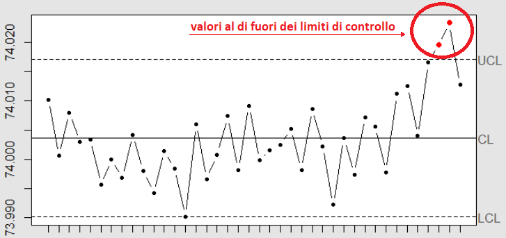

## QCC - Quality Control Charts

**QCC** è un pacchetto R che fornisce strumenti statistici a supporto delle operazioni di controllo e miglioramento della qualità.

QCC permette principalmente la creazione di **diagrammi di controllo**, come:

- Diagrammi di controllo qualità di tipo Shewhart;
- Diagrammi CUSUM e EWMA;
- Curve operative caratteristiche (OC - Operating characteristic curves);
- Analisi delle capacità di processo;
- Diagrammi di Pareto e diagrammi causa-effetto;
- Diagrammi di controllo multivariati.

## Controllo della media campionaria

Caratteristica monitorata: **media campionaria \(\bar{x}\)**

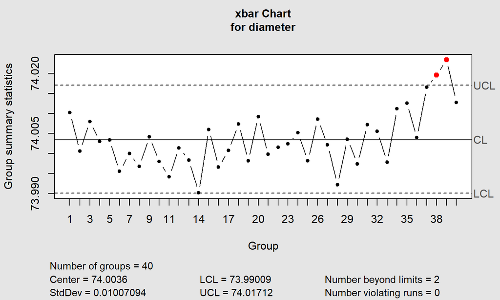

I **limiti di controllo** vengono calcolati sulla base di una opportuna statistica test basata su distribuzione normale standard.

## Controllo della variabilità

Due semplici diagrammi per il controllo della variabilità di processo plottano, in riferimento ai campioni osservati, l’**andamento dei range campionari** e della **deviazione standard campionaria**.

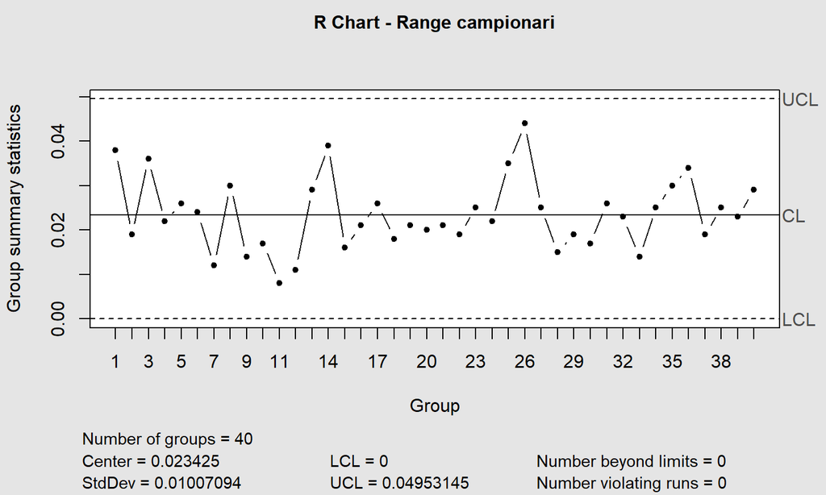

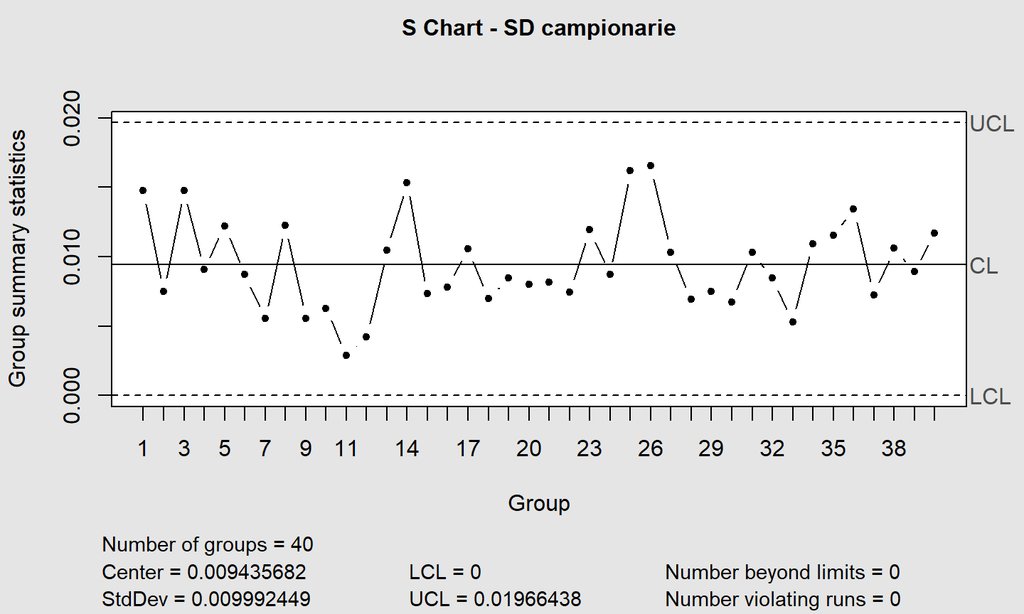

Anche qui, i limiti di controllo vengono calcolati sulla base della distribuzione campionaria di opportune statistiche test.

## Diagrammi CUSUM e EWMA

Principale **svantaggio** dei diagrammi Shewhart: si basano sulle informazioni fornite solo dall’ultimo campione; ignorando l’**andamento** della caratteristica controllata.

Due alternative sono:

- **CUSUM**: **CU**mulative **SUM** control chart
- **EWMA**: **E**xponentially **W**eighted **M**oving **A**verage

**Vantaggio:** permettono il rilevamento di piccole variazioni (anche permanenti) nel processo di produzione.

## Cumulative Sum Control Chart

Esempio esplicativo (*con dati sintetici*):

**Problema:** Un diagramma di controllo, nel caso che queste osservazioni ricadano all’interno dei limiti di controllo non segnalerà mai l’anomalia.

Rappresentazione grafica dell’esempio: **shift di processo non rilevato**

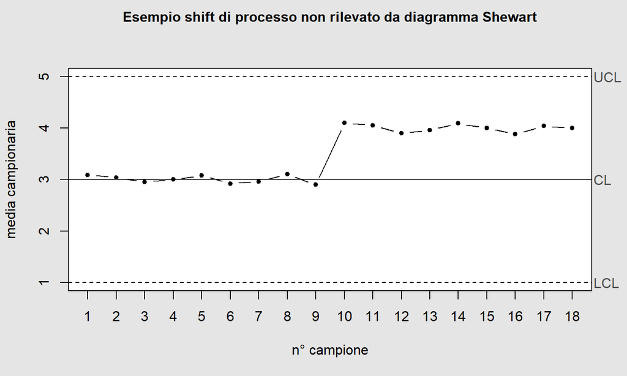

Diagramma delle somme cumualtive sui dati dell’esempio:

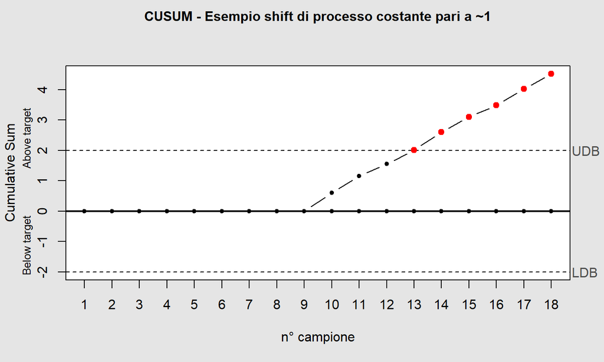

Come possiamo vedere il diagramma **CUSUM** rileva una anomalia, in quanto nel processo è presenta una deviazione permanente dal valore target.

## Exponentially Weighted Moving Average

Il diagramma EWMA è molto simile al diagramam CUSUM: si basa sulla media in movimento, calcolata con pesi che decadono con legge esponenziale (*i dati recenti sono più significativi*).

**Vantaggi:** rilevamento di piccoli shift permanenti sul processo migliore rispetto ai diagrammi Shewhart (migliori per grandi shift).

Segue un altro esempio con dati sintetici.

Rappresentazione grafica dell’esempio: **shift di processo non rilevato**

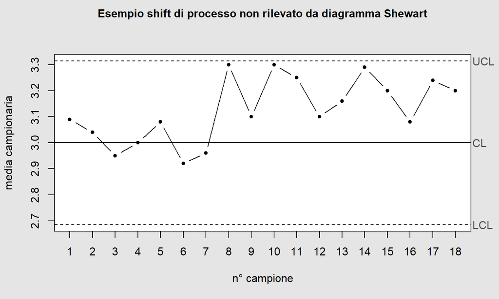

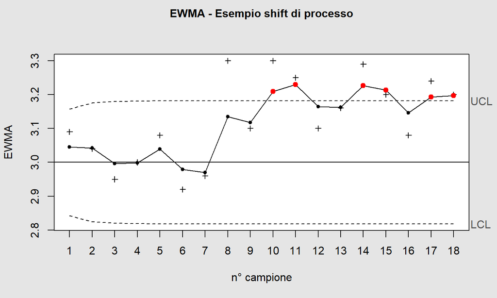

Il diagramma **EWMA**, basandosi sulla media in movimento che sfrutta anche l’informazione delle osservazioni precedenti è in grado di rilevare lo shift di processo.

## Curve caratteristiche di processo

Una **curva caratteristica operativa** fornisce una misura delle performance di un piano di campionamento semplice.

**Campionamento semplice**: un lotto viene sottoposto a una ispezione di qualità:

- \(N\) dimensione del lotto;
- \(n\) dimensione del campione (\(n < N\));
- \(c\) numero di accettazione;
- \(d\) numero di unità difettose osservate.

Si verificheranno due possibili casi:

- \(d>c\): il lotto verrà scartato;
- \(d \leq c\): il lotto sarà accettato.

La curva viene calcolata sotto ipotesi che il campionamento semplice segua legge **Binomiale Bi(n,p)** con \(n=\) dim. campione e \(p=\) fazione difettosi nel campione.

Le curve OC ripotarno il **potere discriminante** del campionamento semplice, riportando la probabilità di commettere un errore di **tipo II** (accettare un lotto che non rispetta il criterio di accettazione).

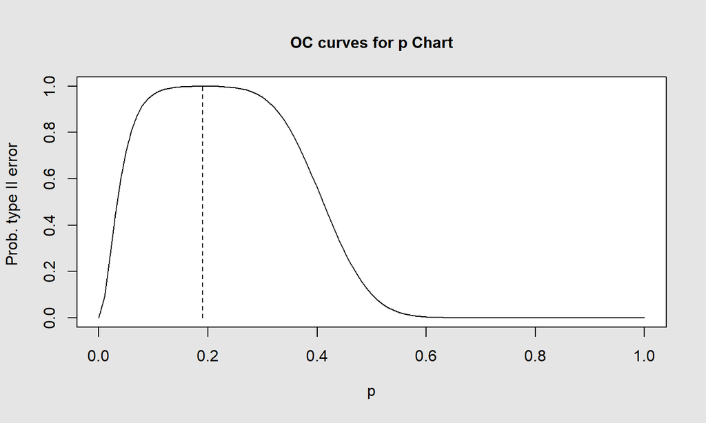

## Analisi capacità di processo

Il seguente diagramma fornisce una stima della **capacità di processo**, ovvero della sua uniformità nel tempo.

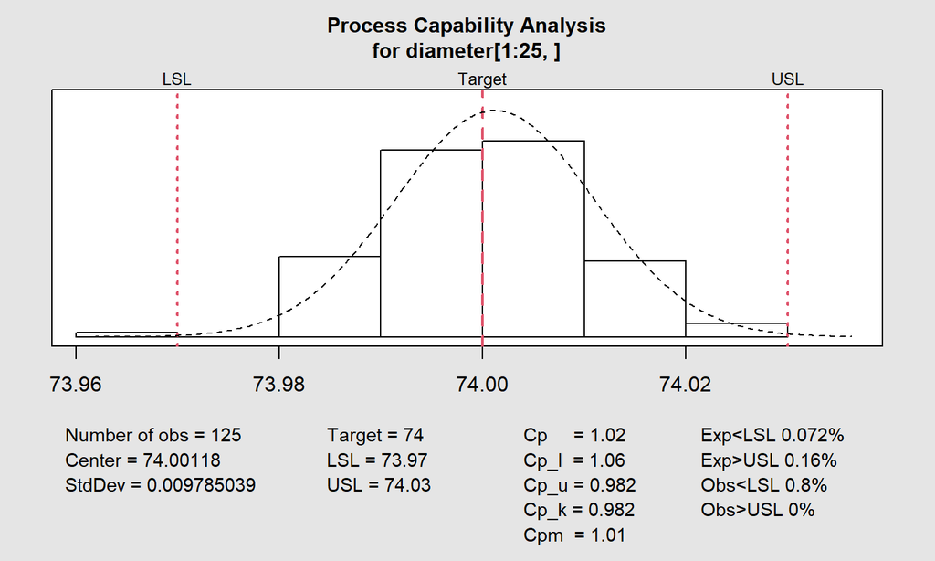

Il valore \(C_{p}\) è una indicazione numerica per esprimere la capacità di processo.

Calcolo di \(C_{p}\): \[ \hat{C_{p}}=\frac{\mathrm{USL}-\mathrm{LSL}}{6 \hat{\sigma}} \] Al diminuire della deviazione standard dei campioni, la capacità di processo \(C_{p}\) aumenta, fornendo quindi indicazione di un processo più stabile.

Il diagramma fornisce anche altre informazioni come:

- n° osservazioni al di fuori dei limiti di controllo
- n° osservazioni al di fuori dei limiti di controllo in base a una approssimazione di distribuzione normale con \(\mu=\) target e dev. std. campionaria.

## Diagramma di Pareto

Un diagramma di pareto è un **barplot** in cui le categorie sono ordinate in ordine decrescente in base alle **frequenze relative**.

Viene tipicamente usato per **identificare i fattori che hanno il maggiore effetto cumulativo sul sistema**.

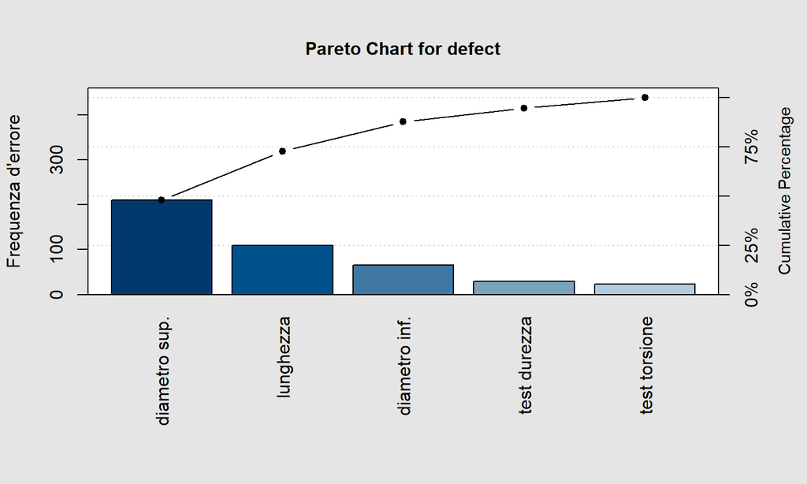

## Diagramma Causa-Effetto

Il diagramma causa effetto viene utilizzato per avere una visione chiara delle associazioni causa-effetto in fase di **prevenzione dei difetti di qualità**.

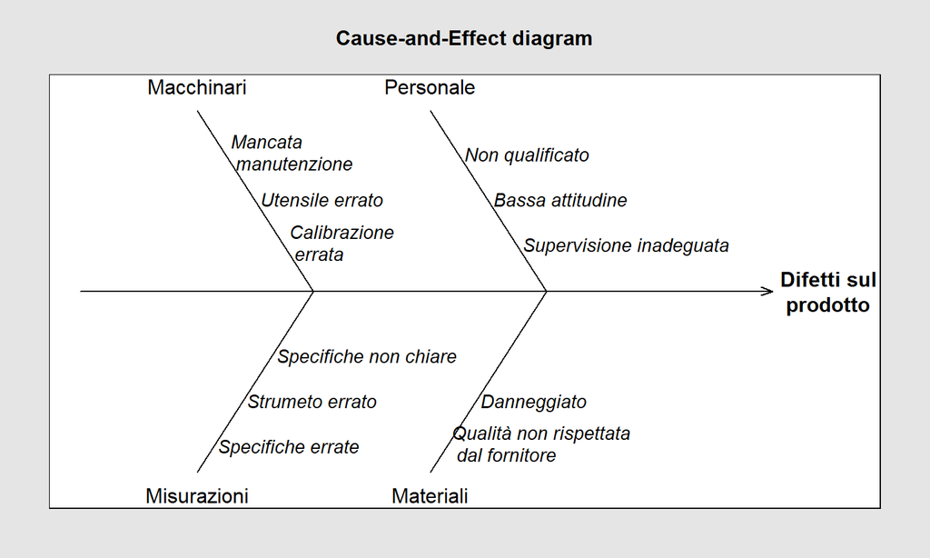

Il diagramma causa-effetto aiuta anche a capire le cause dei difetti (variabilità) nel prodotto finale.

## Diagrammi di controllo Multivariati

In ambito industriale risulta spesso necessario controllare **simultaneamente** l’andamento di **2 o più caratteristiche di qualità** di un prodotto.

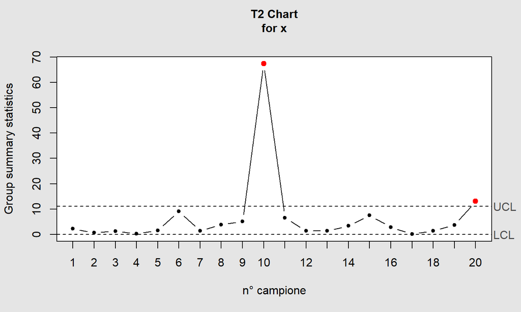

*QCC* ci viene in contro con i **diagrammi di controllo multivariati**, basati sulla legge di distribuzione congiunta delle due o più caratteristiche e su una opportuna statistica.

## Hotelling \(T^2\) e ellipse-chart

Il diagramma riportarto permette di tracciare osservazioni multivariate su un unico grafico, basandosi su una statistica che combina le informazioni della media e la dispersione di più di una variabile (Hotelling \(T^2\))

Nel caso **bivariato** è possibile rappresentare la regione di accettazione con un diagramma ellisse

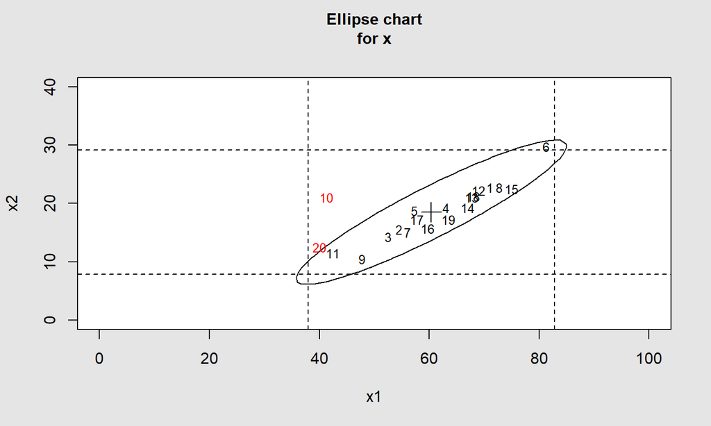

## Conclusioni

**QCC** oltre alle funzionalità di base appena elencate, permette molto altro:

- per ogni diagramma sono presenti molti parametri di configurazione
- fornisce dataset di test
- fornisce svariati metodi alternativi per il calcolo delle varie statistiche (*standard dev, media pesata in movimento, somme cumulative etc. etc.*)
- permette test d’ipotesi
- fornisce molte più varianti dei diagrammi Shewart oltre a quelli illustrati
- etc.